# Clase 2 - Guía de profundización Variables Aleatorias Continuas

Diplomado en Análisis de Datos y Modelamiento Predictivo con Aprendizaje Automático para la Acuicultura.

Dr. José A. Gallardo Matus y Dra. María Angélica Rueda

Pontificia Universidad Católica de Valparaíso  
jose.gallardo@pucv.cl

08 April 2023

### **Introducción**

**¿Cuál es la diferencia entre variable y dato?**

Las **variables** son las características que se pueden medir en un individuo o en un ambiente y los **datos** son los valores que puede tomar esa variable.

**¿Qué es una variable aleatoria?**

Es una variable cuyo valor se determina por el azar. Las variables aleatorias se representan por letras mayúsculas (**X**) y sus valores numéricos por letras minúsculas ($x_i$).

### **Clasificación de variables cuantitativas**

[output not shown]

### **Clasificación de variables cualitativas o categóricas**

| **Tipo de variable** | **Descripción** |
| --- | --- |
| **Variables nominales:** | Sus valores representan categorías que no obedecen a una clasificación intrínseca. |
| **Variables ordinales:** | Sus valores representan categorías con alguna clasificación intrínseca. |

### **Distribución de una variable**

*Distribución empírica (observación)*: Los datos de una muestra, obtenidos de forma aleatoria de una población, pueden ser usados para observar su comportamiento o distribución.

*Distribución de probabilidad (predicción)*: Las variables aleatorias tienen diferentes distribuciones de probabilidad subyacentes, lo que nos permite predecir su comportamiento y realizar inferencia estadística.

*Distribución normal*: Las variables cuantitativas continuas podrían seguir una distribución normal.

### **¿Cómo puedo observar y predecir el comportamiento de una variable?**

En la siguiente tabla se muestran varias **funciones clave** para poder observar o predecir el comportamiento de una variable aleatoria.

| **Librería** | **Función** | **Descripción** |
| --- | --- | --- |
| base | **table()** | Tabla de distribución de frecuencia para factores. |
| base | **plot()** | Gráfico x-y de puntos “p”, líneas “l” o ambas “b”. |
| graphics | **hist()** | Histograma para variables cuantitativas |
| graphics | **boxplot()** | Gráfico de cajas y bigotes |
| graphics | **barplot()** | Gráfico de barras |
| stats | **density()** | Función de densidad empírica |
| stats | **ecdf()** | Función de distribución acumulada empírica |

### **¿Qué puedo medir de una variable aleatoria continua?**

| **Librería** | **Función** | **Descripción** |
| --- | --- | --- |
| base | **mean()** | Media aritmética |
| base | **range()** | Rango |
| stats | **median()** | Mediana |
| stats | **var()** | Varianza |
| stats | **sd()** | Desviación estándar |
| stats | **quantile()** | Concentración de datos en cuantiles |
| stats | **cor()** | Correlación con otra variable |

### **¿Cómo puedo simular números aleatorios con distribución normal?**

| **Librería** | **Función** | **Descripción** |
| --- | --- | --- |
| stats | **rnorm(n, mean, sd)** | Genera (n) números aleatorios para la distribución normal con promedio (mean) y desviación estandar (sd) |

### **Objetivos de aprendizaje**

Los objetivos de aprendizaje de esta guía son:

**1**. Importar, observar y predecir variables aleatorias continuas desde datos reales de salmón.

## **Ejercicios**

### Estudio de caso.

En esta guía trabajaremos con datos reales de producción y calidad de salmón Chinook cultivado [Lajoie et al. 2019](https://doi.org/10.1016/j.aquaculture.2019.03.008.)

### **Ejercicio 1.** **Elaborar un Script de R (Archivo .R)**

Elabore un archivo o file con extensión **.R** usando la barra de herramientas de **Rstudio**. Selecciona **File > New file > R script**. Utilice el siguiente ejemplo para completar la información de **metadatos** del script.

```
# ----------------------------------------------------------
# Clase 02 - Guia Variables Aleatorias continuas.
# Su nombre:
# 09 abril 2023.
# Diplomado en Análisis de Datos y Modelamiento Predictivo con Aprendizaje Automático para la Acuicultura.
# ----------------------------------------------------------
```

Luego, guarde inmediatamente su script como **script_2_nombre_apellido.R**.

### **Ejercicio 2.** **Configuración de paquetes**

Debajo del **metadatos** habilite el paquete **readxl** usando la función **library()**. Note que los paquetes **base**, **stats**, **utils** y **graphics** ya están habilitados.

```r
knitr::opts_chunk$set(echo = FALSE)
library(readxl)
```

### **Ejercicio 3.** **datos de salmón Chinook.**

El set de datos **Salmon_Data.xlsx** contiene información de diferentes variables de producción y calidad, así como de diferentes factores que influyen en estos rasgos.

Cree un objeto llamado **salmones** e importe el set de datos **Salmon_Data.xlsx** usando la función **read_excel** del paquete **readxl**.

Explore el set de datos algunas funciones de la paquete **{utils}** **head()**, **tail()**, **str()**. Explore con el paquete **{base}** y la función **summary**.

```
## # A tibble: 6 × 10
##   Popul…¹ Family Net p…² Weigh…³ Lengt…⁴ Colou…⁵ Fille…⁶ Slaug…⁷ Fat M…⁸ Dry L…⁹
##   <chr>   <chr>  <chr>     <dbl>   <dbl>   <dbl>   <dbl>   <dbl>   <dbl>   <dbl>
## 1 YIAL    369512 9B         2164    48.7    30.2    61.9    91.4     8.9    33.4
## 2 YIAL    91524  9B         1838    47.2    30.2    57.5    90.1     8      25.5
## 3 Puntle… 40     9B         1739    47.7    31      57.4    91.1     7.4    21.9
## 4 Chilli… CH13   9B         1670    45.6    29.1    58.3    90.8     9      28.7
## 5 YIAL    101829 9B         1883    47.4    29.7    64      92.6    10.4    27.6
## 6 Big Qu… 55     9B         1354    42.5    30.5    60.1    90.9     8.7    19.7
## # … with abbreviated variable names ¹Population, ²`Net pen`, ³`Weight (g)`,
## #   ⁴`Length (cm)`, ⁵`Colour Score`, ⁶`Fillet Yield (%)`,
## #   ⁷`Slaughter Yield (%)`, ⁸`Fat Meter (%)`, ⁹`Dry Lipid Concentration (%)`
```

```
## # A tibble: 6 × 10
##   Popul…¹ Family Net p…² Weigh…³ Lengt…⁴ Colou…⁵ Fille…⁶ Slaug…⁷ Fat M…⁸ Dry L…⁹
##   <chr>   <chr>  <chr>     <dbl>   <dbl>   <dbl>   <dbl>   <dbl>   <dbl>   <dbl>
## 1 YIAL    222403 21B        1309    44.3    32.5    59.2    91.9    10     31.9
## 2 YIAL    95776  21B        1411    43.2    30.7    60.6    92.5     6.8   18.5
## 3 Big Qu… 57     21B        1344    43.7    30.7    62.4    92      10.6   21.1
## 4 Big Qu… 50     21B        1239    44.8    32.7    57.5    92.2     7     18.8
## 5 Big Qu… 50     21B        1006    42.2    31.1    62      92.8     8.7    9.89
## 6 YIAL    369512 21B        1733    47.3    30.6    58.3    91.2     8.3   19.8
## # … with abbreviated variable names ¹Population, ²`Net pen`, ³`Weight (g)`,
## #   ⁴`Length (cm)`, ⁵`Colour Score`, ⁶`Fillet Yield (%)`,
## #   ⁷`Slaughter Yield (%)`, ⁸`Fat Meter (%)`, ⁹`Dry Lipid Concentration (%)`
```

```
## tibble [204 × 10] (S3: tbl_df/tbl/data.frame)
##  $ Population                 : chr [1:204] "YIAL" "YIAL" "Puntledge" "Chilliwack" ...
##  $ Family                     : chr [1:204] "369512" "91524" "40" "CH13" ...
##  $ Net pen                    : chr [1:204] "9B" "9B" "9B" "9B" ...
##  $ Weight (g)                 : num [1:204] 2164 1838 1739 1670 1883 ...
##  $ Length (cm)                : num [1:204] 48.7 47.2 47.7 45.6 47.4 42.5 37.3 47.7 43.9 41.9 ...
##  $ Colour Score               : num [1:204] 30.2 30.2 31 29.1 29.7 30.5 30.5 30.5 32 27.5 ...
##  $ Fillet Yield (%)           : num [1:204] 61.9 57.5 57.4 58.3 64 60.1 55.3 60.9 59.6 62.5 ...
##  $ Slaughter Yield (%)        : num [1:204] 91.4 90.1 91.1 90.8 92.6 90.9 91.8 90 91.6 92.3 ...
##  $ Fat Meter (%)              : num [1:204] 8.9 8 7.4 9 10.4 8.7 3 11.3 6.7 9.4 ...
##  $ Dry Lipid Concentration (%): num [1:204] 33.4 25.5 21.9 28.7 27.6 ...
```

```
##   Population           Family            Net pen            Weight (g)
##  Length:204         Length:204         Length:204         Min.   : 287
##  Class :character   Class :character   Class :character   1st Qu.:1228
##  Mode  :character   Mode  :character   Mode  :character   Median :1472
##                                                           Mean   :1452
##                                                           3rd Qu.:1746
##                                                           Max.   :2383
##
##   Length (cm)     Colour Score   Fillet Yield (%) Slaughter Yield (%)
##  Min.   :27.60   Min.   :20.00   Min.   :36.10    Min.   :85.30
##  1st Qu.:42.58   1st Qu.:28.70   1st Qu.:56.05    1st Qu.:90.40
##  Median :44.80   Median :30.50   Median :58.95    Median :91.20
##  Mean   :44.26   Mean   :29.86   Mean   :57.99    Mean   :91.08
##  3rd Qu.:47.02   3rd Qu.:31.70   3rd Qu.:60.42    3rd Qu.:92.00
##  Max.   :52.00   Max.   :34.00   Max.   :64.00    Max.   :95.10
##                                                   NA's   :1
##  Fat Meter (%)    Dry Lipid Concentration (%)
##  Min.   : 1.000   Min.   : 1.28
##  1st Qu.: 6.175   1st Qu.:13.11
##  Median : 8.300   Median :19.73
##  Mean   : 8.086   Mean   :18.81
##  3rd Qu.:10.100   3rd Qu.:25.26
##  Max.   :14.100   Max.   :35.39
##
```

### **Ejercicio 4.** **Transformación a factor**

```
##            Population     Family    Net pen    Weight (g)    Length (cm)
##  Big Qualicum   :41   369512 : 15   21B:81   Min.   : 287   Min.   :27.60
##  Chilliwack     :18   222403 : 12   2B :57   1st Qu.:1228   1st Qu.:42.58
##  Nitinat        : 9   101829 : 11   9B :66   Median :1472   Median :44.80
##  Puntledge      :14   50     : 10            Mean   :1452   Mean   :44.26
##  Quinsam        :24   55     :  9            3rd Qu.:1746   3rd Qu.:47.02
##  Robertson Creek:20   88661  :  9            Max.   :2383   Max.   :52.00
##  YIAL           :78   (Other):138
##   Colour Score   Fillet Yield (%) Slaughter Yield (%) Fat Meter (%)
##  Min.   :20.00   Min.   :36.10    Min.   :85.30       Min.   : 1.000
##  1st Qu.:28.70   1st Qu.:56.05    1st Qu.:90.40       1st Qu.: 6.175
##  Median :30.50   Median :58.95    Median :91.20       Median : 8.300
##  Mean   :29.86   Mean   :57.99    Mean   :91.08       Mean   : 8.086
##  3rd Qu.:31.70   3rd Qu.:60.42    3rd Qu.:92.00       3rd Qu.:10.100
##  Max.   :34.00   Max.   :64.00    Max.   :95.10       Max.   :14.100
##                                   NA's   :1
##  Dry Lipid Concentration (%)
##  Min.   : 1.28
##  1st Qu.:13.11
##  Median :19.73
##  Mean   :18.81
##  3rd Qu.:25.26
##  Max.   :35.39
##
```

```
## tibble [204 × 10] (S3: tbl_df/tbl/data.frame)
##  $ Population                 : Factor w/ 7 levels "Big Qualicum",..: 7 7 4 2 7 1 4 1 7 7 ...
##  $ Family                     : Factor w/ 58 levels "1","10","101829",..: 23 49 28 54 3 40 30 36 23 50 ...
##  $ Net pen                    : Factor w/ 3 levels "21B","2B","9B": 3 3 3 3 3 3 3 3 3 3 ...
##  $ Weight (g)                 : num [1:204] 2164 1838 1739 1670 1883 ...
##  $ Length (cm)                : num [1:204] 48.7 47.2 47.7 45.6 47.4 42.5 37.3 47.7 43.9 41.9 ...
##  $ Colour Score               : num [1:204] 30.2 30.2 31 29.1 29.7 30.5 30.5 30.5 32 27.5 ...
##  $ Fillet Yield (%)           : num [1:204] 61.9 57.5 57.4 58.3 64 60.1 55.3 60.9 59.6 62.5 ...
##  $ Slaughter Yield (%)        : num [1:204] 91.4 90.1 91.1 90.8 92.6 90.9 91.8 90 91.6 92.3 ...
##  $ Fat Meter (%)              : num [1:204] 8.9 8 7.4 9 10.4 8.7 3 11.3 6.7 9.4 ...
##  $ Dry Lipid Concentration (%): num [1:204] 33.4 25.5 21.9 28.7 27.6 ...
```

### **Ejercicio 5.** **Observar el comportamiento de una variable**

A partir del set de datos **salmones** elabore un histograma y un boxplot de la variable cuantitativa continua **Weight (g)**. Use las funciones **hist()**, **boxplot()**. Incluya títulos y leyenda de los ejes con los argumentos *col=““*,* main =”“* y *xlab=““*.

Investigue y use este comando **par(mfrow=c(1,2))** para unir las gráficas en un solo panel con dos columnas.

¿Que representan los círculos que aparece en el Boxplot?.

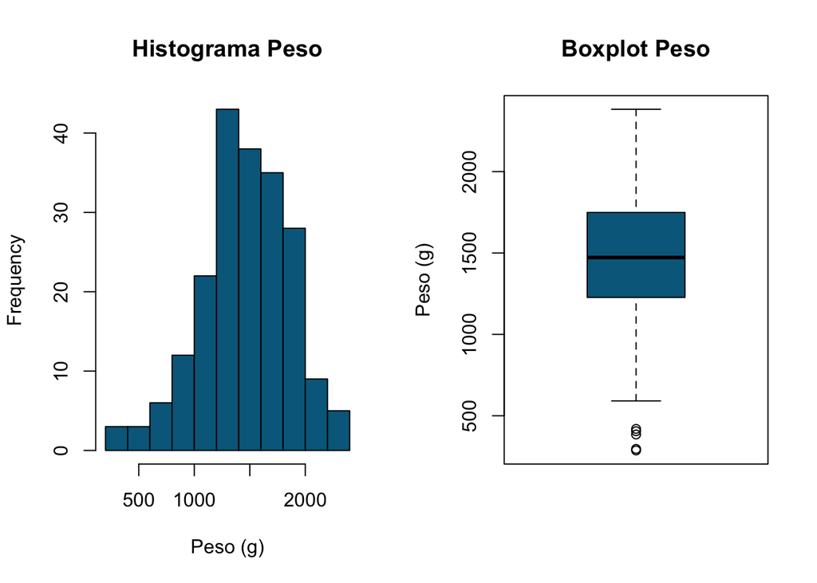

### **Ejercicio 6.** **Métricas del set de datos salmones**

Calcule las siguientes métricas para **Weight (g)**del set de datos: promedio, desviación estándar, rango y cuantiles usando las funciones: **mean()**, **sd()**, **range()** y **quantile()**.

```
## [1] 1452.397
```

```
## [1] 402.8988
```

```
## [1]  287 2383
```

```
##     0%    25%    50%    75%   100%
##  287.0 1227.5 1472.0 1746.5 2383.0
```

### **Ejercicio 7.** **Función de densidad**

Usando la función **plot()** elabore:

**a).** Gráfico con la densidad empírica de la variable **Weight (g)**. Debe incluir la función **density()** dentro de la función **plot()**.

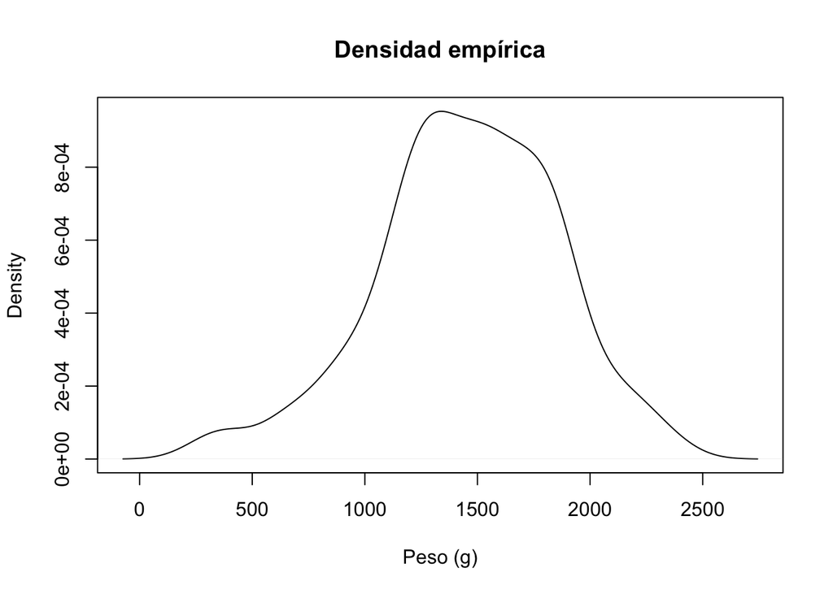

**b).** Gráfico con la distribución acumulada empírica. Debe incluir la función **ecdf()** dentro de la función **plot()**.

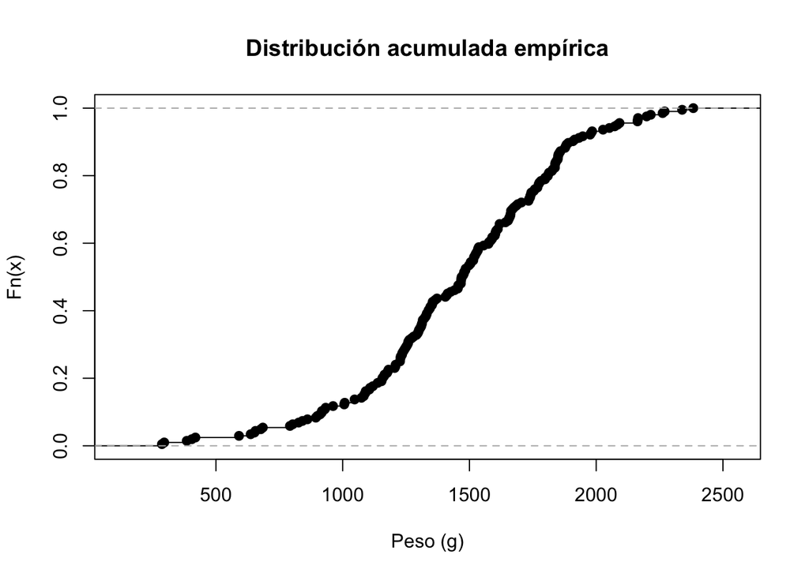

```r
# Distribución acumulada empírica.
plot(ecdf(salmones$`Weight (g)`), main="Distribución acumulada empírica", xlab="Peso (g)")
```

### **Ejercicio 8.** **Crear una función y predecir datos observados**

Utilice la función de distribución acumulada empírica **ecdf()** para determinar que proporción de los animales es menor a 1000 g, y que proporción es mayor de 2000 g:

**a).** Primero cree un un objeto llamado **Fn** con la función de distribución acumulada empírica para los datos del peso de sus animales.

```r
Fn <- ecdf(salmones$`Weight (g)`)
Fn
```

```
## Empirical CDF
## Call: ecdf(salmones$`Weight (g)`)
##  x[1:189] =    287,    296,    385,  ...,   2339,   2383
```

```r
# Fn(x) returns the percentiles for x
paste("La proporción de animales menores a 1000 g es = ", Fn(1000)*100, "%")
```

```
## [1] "La proporción de animales menores a 1000 g es =  11.7647058823529 %"
```

```r
# 1- Fn(x) returns 1 - the percentiles for x
paste("La proporción de animales mayores a 2000 g es = ", ((1 - Fn(2000))*100), "%")
```

```
## [1] "La proporción de animales mayores a 2000 g es =  6.86274509803921 %"
```